# Midterm 2 W26 - Corrections

2026-03-06

## Instructions

This is an in-person exam. Your exam must be complete and uploaded to Gradescope by 2:00p.

Answer the following questions and complete the exercises in RMarkdown. Please embed all of your code and push your final work to your repository. Your code must be organized, clean, and run free from errors. Remember, you must remove the `#` for any included code chunks to run. Be sure to add your name to the author header above.

Your code must knit in order to be considered. If you are stuck and cannot answer a question, then comment out your code and knit the document. You may use your notes, labs, and homework to help you complete this exam. Do not use any other resources- including AI assistance or other students’ work.

Don’t forget to answer any questions that are asked in the prompt! Each question must be coded; it cannot be answered by a sort in a spreadsheet or a written response only.

For all plots you create, a title and clearly labeled axes must be provided.

Be sure to push your completed midterm to your repository and upload the document to Gradescope. *Incorrectly uploading the exam to Gradescope will result in a 5 point deduction.* This exam is worth 50 points.

## Load the libraries

```r
library(tidyverse)
library(janitor)
library(naniar)
library(ggmap)
library(lubridate)
library(shiny)
```

## API Key

Since you will build a map as part of the exam, take a moment to register your API key. You may need to look up your [stadia maps](https://client.stadiamaps.com/dashboard/overview) API key online (please do that now).

```r
register_stadiamaps("efbbad0c-b639-4a5e-bc42-a820b574fc9b", write = FALSE)
```

## About the data

This study is focused on the fasting behavior of polar bears in the Southern Beaufort (SB) and Chukchi seas (CS). The data were collected from 1983-2017 and include measurements of blood urea nitrogen (BUN) and creatinine, which are used to calculate a ratio that indicates whether a bear is fasting or not. The original paper is included in the data folder. *It may help to quickly read the abstract before starting the exam.*

The data are from: Rode, K.D., Wilson, R.R., Douglas, D.C., Muhlenbruch, V., Atwood, T.C., Regehr, E.V., Richardson, E.S., Pilfold, N.W., Derocher, A.E., Durner, G.M., Stirling, I., Amstrup, S.C., St. Martin, M., Pagano, A.M., and others, 2017, Spring fasting behavior in a marine apex predator provides an index of ecosystem productivity: Global Change Biology, v. 24, no. 1, p. 410–423, https://doi.org/10.1111/gcb.13933.

## Data resources

- https://data.usgs.gov/datacatalog/data/USGS:ASC141
- https://www.sciencebase.gov/catalog/item/61a1a9e7d34eb622f69743d2

## The variables include:

- `bear_id`: A unique number given to each bear.
- `capture_date`: The data when the bear was tranquilized and assessed.
- `popn`: The population to which the bear belongs.
- `sex`: Sex of each bear.
- `age_class`: The age class of each bear (A=adult, S=subadult).
- `mating`: Whether or not the bear is pursuing a mate.
- `denning`: Whether or not the bear denned last year.
- `lat`: Latitude where the bear was located.
- `long`: Longitude where the bear was located.
- `urea_nitrogen`: Concentration of urea nitrogen.
- `creatinine`: Concentration of creatinine.

## Load the data

Run the code chunk below to load the data, clean the names, and do some tidying.

```r
polar_bears <-
  read_csv("data/polarBear_serumUreaCreatinine_beaufortChukchi_rode.csv") %>%
  clean_names() %>%
  select(-den_method, -no_cubs, -cub_age) %>%
  filter(age_class==c("A", "S")) %>%
  mutate(sex=toupper(sex),
         age_class=toupper(age_class))
```

```r
polar_bears <- polar_bears %>% #going back to the original data
  replace_with_na(replace = list(mating = "unknown",
                                 denning = "unknown")) #found unknown in denning as well through inspection
```

```r
polar_bears %>%
  summarize(across(everything(), ~ sum(is.na(.))))
```

```
## # A tibble: 1 × 11
##   bear_id capture_date  popn   sex age_class mating denning   lat  long
##     <int>        <int> <int> <int>     <int>  <int>   <int> <int> <int>
## 1       0            0     0     0         0    299      91     0     0
## # ℹ 2 more variables: urea_nitrogen <int>, creatinine <int>
```

3. (6 points) Is sampling even for both sexes? Make a count the shows the number of males and females sampled by population and make a plot to visualize the counts.

```r
polar_bears %>%
  select(sex) %>%
  count(sex)
```

```
## # A tibble: 2 × 2
##   sex       n
##   <chr> <int>
## 1 F       292
## 2 M       227
```

The sampling is not even as there are more much more females than males.

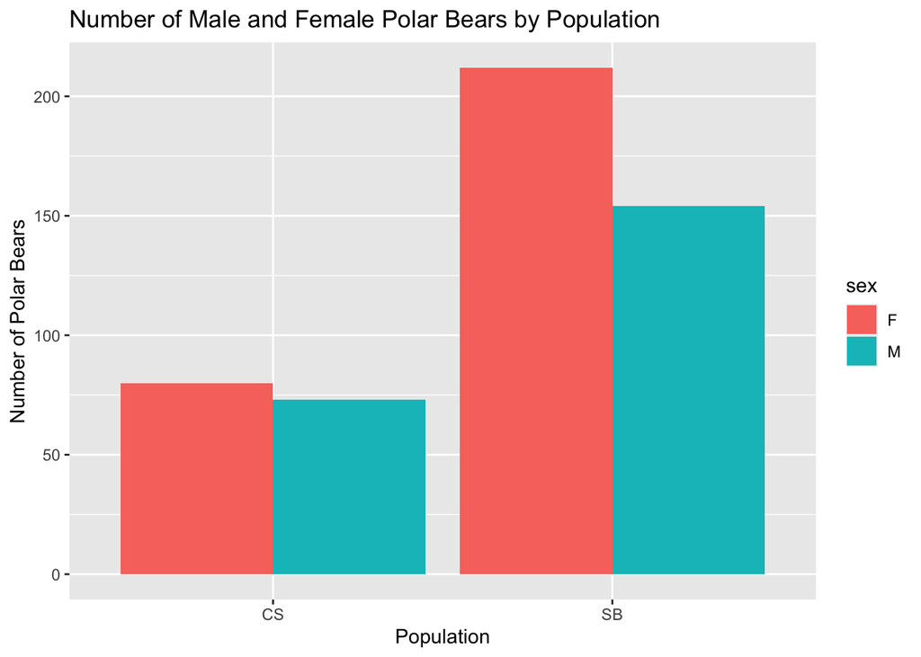

```r
polar_bears %>%
  ggplot(mapping = aes(x = popn, fill = sex)) +
  geom_bar(position = "dodge") +
  labs(title = "Number of Male and Female Polar Bears by Population",
      x = "Population",
      y = "Number of Polar Bears")
```

The error made above was that the count was only by sex and not by population and sex. The corrected code is below:

```r
polar_bears %>%
  select(sex, popn) %>%
  count(sex, popn)
```

```
## # A tibble: 4 × 3
##   sex   popn      n
##   <chr> <chr> <int>
## 1 F     CS       80
## 2 F     SB      212
## 3 M     CS       73
## 4 M     SB      154
```

The sampling is not even as there are more much more females than males between the two populations.

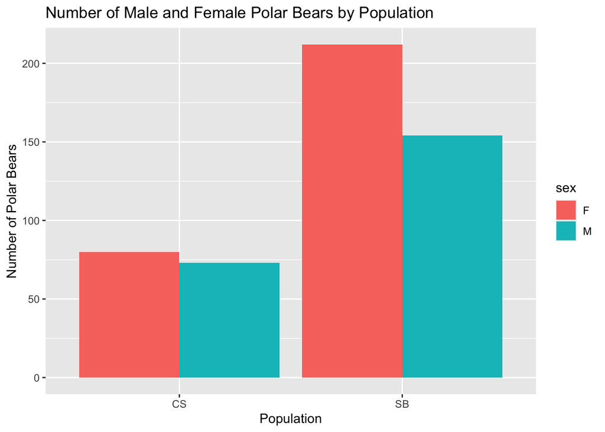

```r
polar_bears %>%
  ggplot(mapping = aes(x = popn, fill = sex)) +
  geom_bar(position = "dodge") +
  labs(title = "Number of Male and Female Polar Bears by Population",
      x = "Population",
      y = "Number of Polar Bears")
```

4. (6 points) How many bears were sampled in each year for both populations? Make a line plot(s) to visualize sampling by year for both populations. (hint: you will need to pull apart the date to get the year in its own column)

```r
polar_bears <- polar_bears %>%
  separate(capture_date, into = c("year", "month", "day"), sep = "-")
polar_bears
```

```
## # A tibble: 519 × 13
##    bear_id year  month day   popn  sex   age_class mating denning   lat  long
##      <dbl> <chr> <chr> <chr> <chr> <chr> <chr>     <chr>  <chr>   <dbl> <dbl>
##  1    6398 1985  04    28    SB    F     A         no     yes      70.4 -148.
##  2    6384 1991  04    13    SB    F     A         no     yes      70.0 -150.
##  3    6520 1992  04    18    SB    F     A         no     yes      70.9 -145.
##  4    6559 2000  04    12    SB    F     A         no     yes      70.0 -142.
##  5   20629 2003  04    16    SB    F     A         no     yes      70.5 -145.
##  6   20876 2007  04    01    SB    F     A         no     yes      71.1 -153.
##  7   20354 2009  04    16    SB    F     A         no     yes      70.7 -145.
##  8   21024 2009  04    25    SB    F     A         no     yes      70.5 -147.
##  9   20764 2009  05    01    SB    F     A         no     yes      70.8 -149.
## 10   21045 2009  05    19    SB    F     A         no     yes      70.7 -148.
## # ℹ 509 more rows
## # ℹ 2 more variables: urea_nitrogen <dbl>, creatinine <dbl>
```

```r
polar_bears %>%
  filter(popn == "SB") %>%
  select(year) %>%
  count(year) %>%
  arrange(desc(n))
```

```
## # A tibble: 27 × 2
##    year      n
##    <chr> <int>
##  1 2009     41
##  2 2010     24
##  3 2012     22
##  4 2003     21
##  5 2004     21
##  6 2001     17
##  7 2011     17
##  8 2002     16
##  9 2006     16
## 10 2005     15
## # ℹ 17 more rows
```

```r
polar_bears %>%
  filter(popn == "CS") %>%
  select(year) %>%
  count(year) %>%
  arrange(desc(n))
```

```
## # A tibble: 14 × 2
##    year      n
##    <chr> <int>
##  1 2013     21
##  2 2016     21
##  3 2011     20
##  4 2010     19
##  5 2009     15
##  6 2008     13
##  7 2015     11
##  8 1988      8
##  9 1989      7
## 10 1992      7
## 11 1990      4
## 12 1991      4
## 13 1987      2
## 14 1993      1
```

```
## `geom_line()`: Each group consists of only one observation.
## ℹ Do you need to adjust the group aesthetic?
```

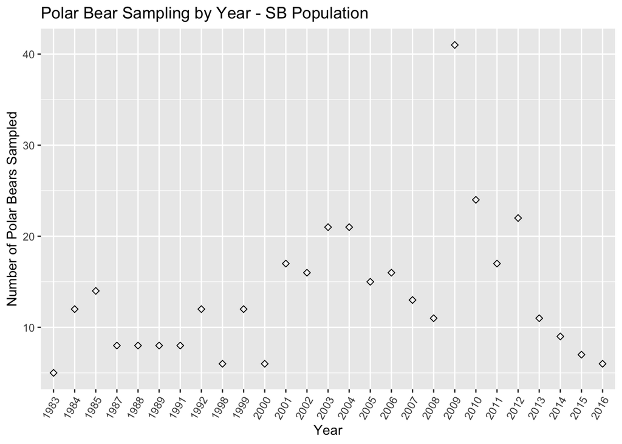

```r
polar_bears %>% #Make a line plot(s) to visualize sampling by year for both populations.
  filter(popn == "SB") %>%
  select(year) %>%
  count(year) %>%
  ggplot(aes(x = year, y = n)) +
  geom_line() +
  geom_point(shape = 5) +
  theme(axis.text.x = element_text(angle = 60, hjust = 1)) +
  labs(title = "Polar Bear Sampling by Year - SB Population",
      x = "Year",
       y = "Number of Polar Bears Sampled")
```

```
## `geom_line()`: Each group consists of only one observation.
## ℹ Do you need to adjust the group aesthetic?
```

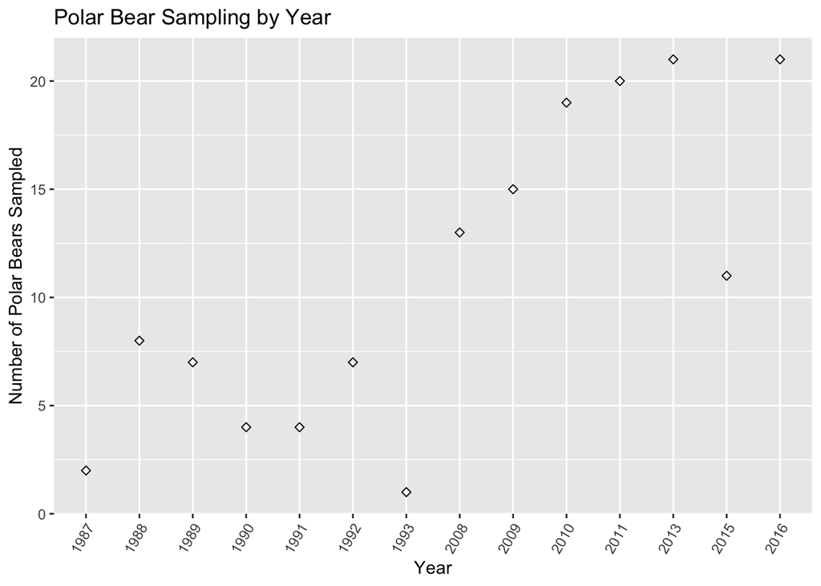

```r
polar_bears %>% #Make a line plot(s) to visualize sampling by year for both populations.
  filter(popn == "CS") %>%
  select(year) %>%
  count(year) %>%
  ggplot(aes(x = year, y = n)) +
  geom_line() +
  geom_point(shape = 5) +
  theme(axis.text.x = element_text(angle = 60, hjust = 1)) +
  labs(title = "Polar Bear Sampling by Year",
      x = "Year",
       y = "Number of Polar Bears Sampled")
```

The error made above was that the line plots did not have lines plotted. The corrected code is below:

```r
#polar_bears <- polar_bears %>% #same code as before
#  separate(capture_date, into = c("year", "month", "day"), sep = "-")
#polar_bears
```

```r
polar_bears %>%
  filter(popn == "SB") %>%
  select(year) %>%
  count(year) %>%
  arrange(desc(n))
```

```
## # A tibble: 27 × 2
##    year      n
##    <chr> <int>
##  1 2009     41
##  2 2010     24
##  3 2012     22
##  4 2003     21
##  5 2004     21
##  6 2001     17
##  7 2011     17
##  8 2002     16
##  9 2006     16
## 10 2005     15
## # ℹ 17 more rows
```

```r
polar_bears %>%
  filter(popn == "CS") %>%
  select(year) %>%
  count(year) %>%
  arrange(desc(n))
```

```
## # A tibble: 14 × 2
##    year      n
##    <chr> <int>
##  1 2013     21
##  2 2016     21
##  3 2011     20
##  4 2010     19
##  5 2009     15
##  6 2008     13
##  7 2015     11
##  8 1988      8
##  9 1989      7
## 10 1992      7
## 11 1990      4
## 12 1991      4
## 13 1987      2
## 14 1993      1
```

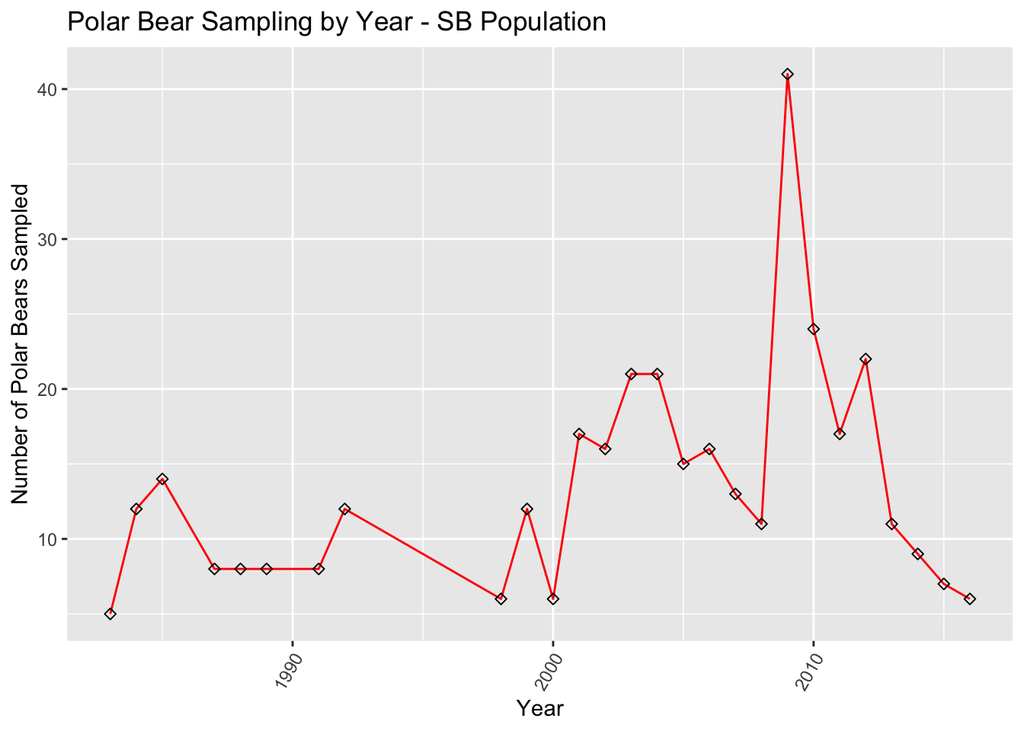

```r
polar_bears %>%
  filter(popn == "SB") %>%
  mutate(year = as.numeric(year)) %>%
  select(year)  %>%
  count(year) %>%
  ggplot(aes(x = year, y = n)) +
  geom_line(color = "red") +
  geom_point(shape = 5) +
  theme(axis.text.x = element_text(angle = 60, hjust = 1)) +
  labs(title = "Polar Bear Sampling by Year - SB Population",
      x = "Year",
       y = "Number of Polar Bears Sampled")
```

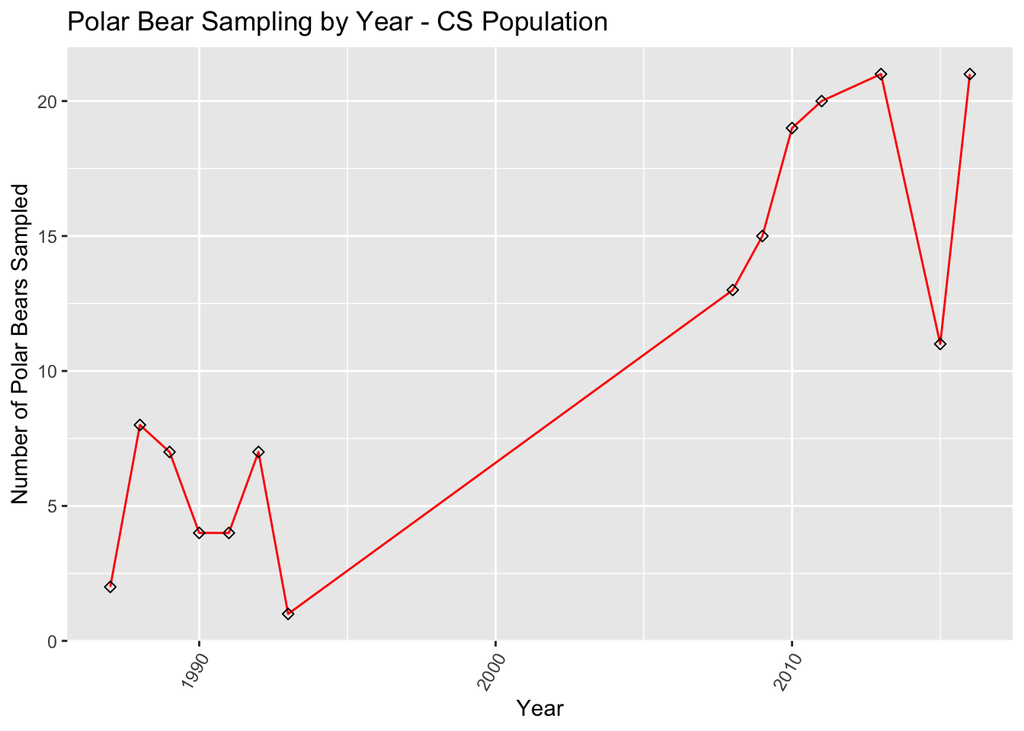

```r
polar_bears %>%
  filter(popn == "CS") %>%
  mutate(year = as.numeric(year)) %>%
  select(year)  %>%
  count(year) %>%
  ggplot(aes(x = year, y = n)) +
  geom_line(color = "red") +
  geom_point(shape = 5) +
  theme(axis.text.x = element_text(angle = 60, hjust = 1)) +
  labs(title = "Polar Bear Sampling by Year - CS Population",
      x = "Year",
       y = "Number of Polar Bears Sampled")
```

```r
polar_bears <- polar_bears %>%
  mutate(un_creat_ratio = (urea_nitrogen * 0.466) / creatinine)
polar_bears
```

```
## # A tibble: 519 × 14
##    bear_id year  month day   popn  sex   age_class mating denning   lat  long
##      <dbl> <chr> <chr> <chr> <chr> <chr> <chr>     <chr>  <chr>   <dbl> <dbl>
##  1    6398 1985  04    28    SB    F     A         no     yes      70.4 -148.
##  2    6384 1991  04    13    SB    F     A         no     yes      70.0 -150.
##  3    6520 1992  04    18    SB    F     A         no     yes      70.9 -145.
##  4    6559 2000  04    12    SB    F     A         no     yes      70.0 -142.
##  5   20629 2003  04    16    SB    F     A         no     yes      70.5 -145.
##  6   20876 2007  04    01    SB    F     A         no     yes      71.1 -153.
##  7   20354 2009  04    16    SB    F     A         no     yes      70.7 -145.
##  8   21024 2009  04    25    SB    F     A         no     yes      70.5 -147.
##  9   20764 2009  05    01    SB    F     A         no     yes      70.8 -149.
## 10   21045 2009  05    19    SB    F     A         no     yes      70.7 -148.
## # ℹ 509 more rows
## # ℹ 3 more variables: urea_nitrogen <dbl>, creatinine <dbl>,
## #   un_creat_ratio <dbl>
```

```r
polar_bears <- polar_bears %>%
  mutate(fasting = case_when(un_creat_ratio <= 10 ~ "yes",
                             un_creat_ratio > 10 ~ "no"))
polar_bears
```

```
## # A tibble: 519 × 15
##    bear_id year  month day   popn  sex   age_class mating denning   lat  long
##      <dbl> <chr> <chr> <chr> <chr> <chr> <chr>     <chr>  <chr>   <dbl> <dbl>
##  1    6398 1985  04    28    SB    F     A         no     yes      70.4 -148.
##  2    6384 1991  04    13    SB    F     A         no     yes      70.0 -150.
##  3    6520 1992  04    18    SB    F     A         no     yes      70.9 -145.
##  4    6559 2000  04    12    SB    F     A         no     yes      70.0 -142.
##  5   20629 2003  04    16    SB    F     A         no     yes      70.5 -145.
##  6   20876 2007  04    01    SB    F     A         no     yes      71.1 -153.
##  7   20354 2009  04    16    SB    F     A         no     yes      70.7 -145.
##  8   21024 2009  04    25    SB    F     A         no     yes      70.5 -147.
##  9   20764 2009  05    01    SB    F     A         no     yes      70.8 -149.
## 10   21045 2009  05    19    SB    F     A         no     yes      70.7 -148.
## # ℹ 509 more rows
## # ℹ 4 more variables: urea_nitrogen <dbl>, creatinine <dbl>,
## #   un_creat_ratio <dbl>, fasting <chr>
```

8. (6 points) The authors found that the number of fasting bears increased in the SB population but decreased in the CS population. Make a plot(s) that shows the number of fasting bears by year for both populations to visualize this trend.

```
## `geom_line()`: Each group consists of only one observation.
## ℹ Do you need to adjust the group aesthetic?
```

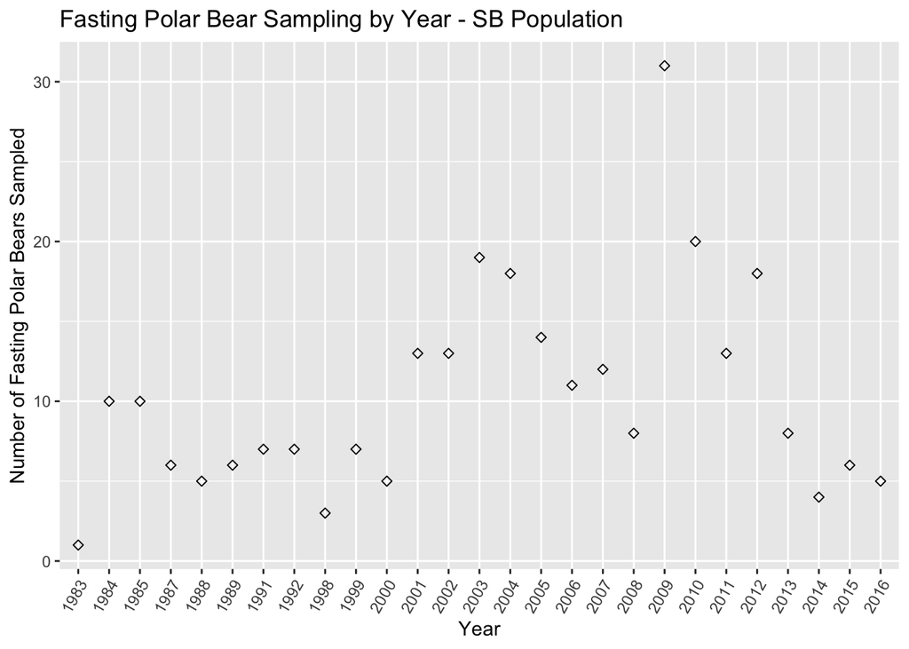

```r
polar_bears %>% #Make a line plot(s) to visualize sampling by year for both populations.
  filter(popn == "SB", fasting == "yes") %>%
  select(year) %>%
  count(year) %>%
  ggplot(aes(x = year, y = n)) +
  geom_line(color = "red") +
  geom_point(shape = 5) +
  theme(axis.text.x = element_text(angle = 60, hjust = 1)) +
  labs(title = "Fasting Polar Bear Sampling by Year - SB Population",
      x = "Year",
       y = "Number of Fasting Polar Bears Sampled")
```

```
## `geom_line()`: Each group consists of only one observation.
## ℹ Do you need to adjust the group aesthetic?
```

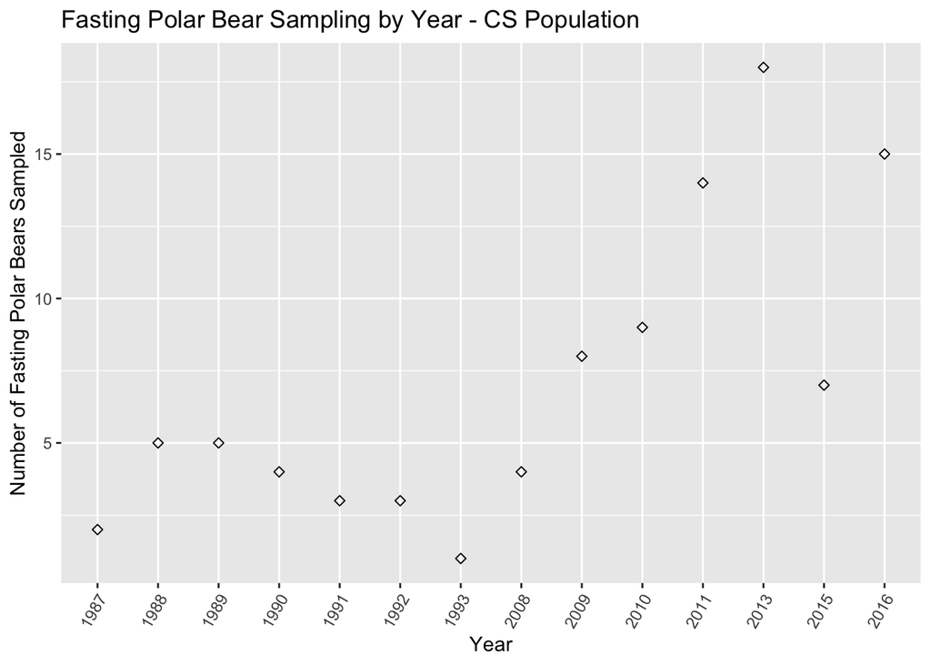

```r
polar_bears %>% #Make a line plot(s) to visualize sampling by year for both populations.
  filter(popn == "CS", fasting == "yes") %>%
  select(year) %>%
  count(year) %>%
  ggplot(aes(x = year, y = n)) +
  geom_line(color = "red") +
  geom_point(shape = 5) +
  theme(axis.text.x = element_text(angle = 60, hjust = 1)) +
  labs(title = "Fasting Polar Bear Sampling by Year - CS Population",
      x = "Year",
       y = "Number of Fasting Polar Bears Sampled")
```

The error made above was that the line plots did not have lines plotted. The corrected code is below:

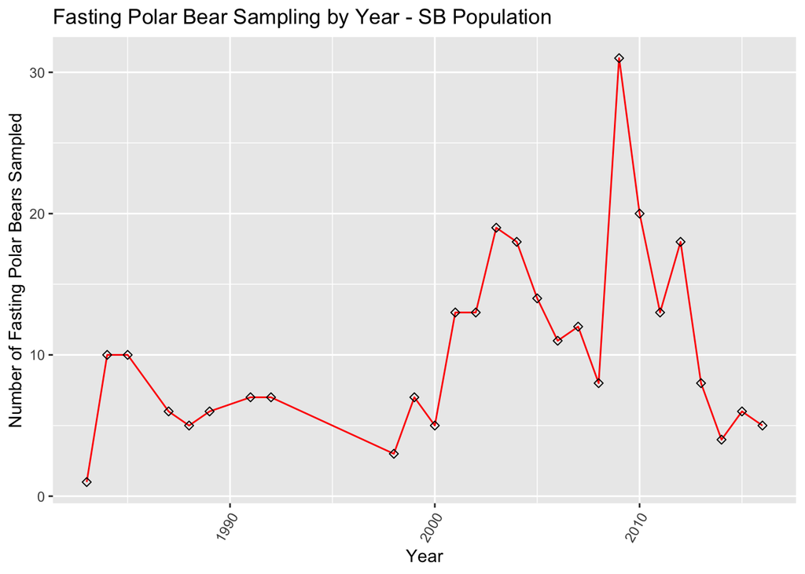

```r
polar_bears %>% #Make a line plot(s) to visualize sampling by year for both populations.
  filter(popn == "SB", fasting == "yes") %>%
  mutate(year = as.numeric(year)) %>%
  select(year) %>%
  count(year) %>%
  ggplot(aes(x = year, y = n)) +
  geom_line(color = "red") +
  geom_point(shape = 5) +
  theme(axis.text.x = element_text(angle = 60, hjust = 1)) +
  labs(title = "Fasting Polar Bear Sampling by Year - SB Population",
      x = "Year",
       y = "Number of Fasting Polar Bears Sampled")
```

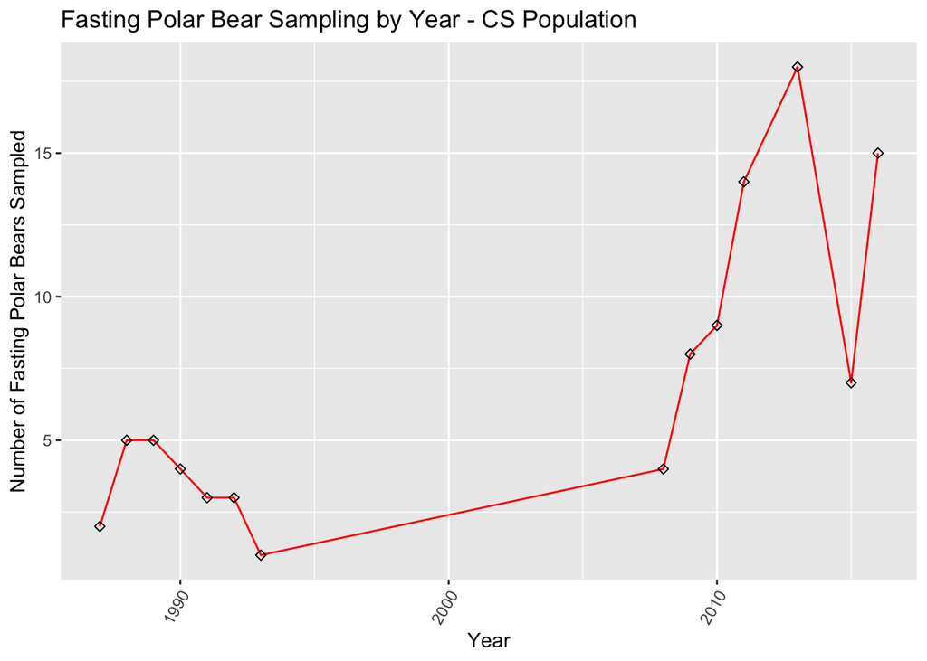

```r
polar_bears %>% #Make a line plot(s) to visualize sampling by year for both populations.
  filter(popn == "CS", fasting == "yes") %>%
  mutate(year = as.numeric(year)) %>%
  select(year) %>%
  count(year) %>%
  ggplot(aes(x = year, y = n)) +
  geom_line(color = "red") +
  geom_point(shape = 5) +
  theme(axis.text.x = element_text(angle = 60, hjust = 1)) +
  labs(title = "Fasting Polar Bear Sampling by Year - CS Population",
      x = "Year",
       y = "Number of Fasting Polar Bears Sampled")
```

## Submit the Midterm

1. Save your work and knit the .rmd file.
2. Open the .html file and “print” it to a .pdf file in Google Chrome (not Safari).
3. Go to the class Canvas page and open Gradescope.
4. Submit your .pdf file to the midterm assignment- be sure to assign the pages to the correct questions.
5. Commit and push your work to your repository.